# 利用集群分析洞悉使用者行為

沈辰禧，台灣大學商研碩士

2018年8月

## 資料輸入與前處理

首先，我們讀入兩個主要用來分析的資料集。

```r
library(tidyverse)
library(knitr)

GameLog <- read.csv('Game_Log.csv')
UserTable <- read.csv('User_Table.csv')
```

先來看看讀進來的這兩筆資料：

```r
str(GameLog)
```

```
## 'data.frame':    4600 obs. of  7 variables:
##  $ User_Id : Factor w/ 920 levels "021ViplNqr","03DaAFruM2",..: 801 801 801 801 801 881 881 881 881 881 ...
##  $ Min_Aft : int  4 6 5 6 5 5 5 6 4 4 ...
##  $ Min_Eve : int  11 19 9 8 10 13 6 15 11 13 ...
##  $ Min_Mid : int  128 76 108 92 94 146 14 85 142 116 ...
##  $ Buy_Coin: int  0 0 0 0 0 0 0 0 0 0 ...
##  $ Buy_Dia : int  673 837 650 668 676 539 568 392 566 494 ...
##  $ Buy_Car : int  30 25 17 30 32 37 30 37 24 27 ...
```

```r
str(UserTable)
```

```
## 'data.frame':    920 obs. of  3 variables:
##  $ User_Id : Factor w/ 920 levels "021ViplNqr","03DaAFruM2",..: 801 881 578 853 57 128 201 93 268 71 ...
##  $ Identity: Factor w/ 3 levels "Normal","Novice",..: 3 3 2 3 1 3 3 3 3 3 ...
##  $ Telecom : Factor w/ 2 levels "ABC","other": 2 2 2 2 2 2 2 2 2 2 ...
```

```r
kable(GameLog[1:10,])
```

| User_Id | Min_Aft | Min_Eve | Min_Mid | Buy_Coin | Buy_Dia | Buy_Car |
| --- | --- | --- | --- | --- | --- | --- |
| wCjAazzKFE | 4 | 11 | 128 | 0 | 673 | 30 |
| wCjAazzKFE | 6 | 19 | 76 | 0 | 837 | 25 |
| wCjAazzKFE | 5 | 9 | 108 | 0 | 650 | 17 |
| wCjAazzKFE | 6 | 8 | 92 | 0 | 668 | 30 |
| wCjAazzKFE | 5 | 10 | 94 | 0 | 676 | 32 |
| yz2XqTDEdo | 5 | 13 | 146 | 0 | 539 | 37 |
| yz2XqTDEdo | 5 | 6 | 14 | 0 | 568 | 30 |
| yz2XqTDEdo | 6 | 15 | 85 | 0 | 392 | 37 |
| yz2XqTDEdo | 4 | 11 | 142 | 0 | 566 | 24 |
| yz2XqTDEdo | 4 | 13 | 116 | 0 | 494 | 27 |

```r
kable(UserTable[1:10,])
```

| User_Id | Identity | Telecom |
| --- | --- | --- |
| wCjAazzKFE | Veteran | other |
| yz2XqTDEdo | Veteran | other |
| OKarWhWKiL | Novice | other |
| y2CJzQ1jTK | Veteran | other |
| 4S1m66UrG3 | Normal | other |
| 9luMsT5otV | Veteran | other |
| c9hYZgHrTT | Veteran | other |
| 7lWiohi7kH | Veteran | other |
| dz2VkYlnk0 | Veteran | other |
| 5SwqlMgl50 | Veteran | other |

將遊戲記錄以及會員資訊以`User_Id`進行`inner_join`

```r
GameTable <- GameLog %>%
  group_by(User_Id) %>%
  summarise(
    Min_Aft = mean(Min_Aft),
    Min_Eve = mean(Min_Eve),
    Min_Mid = mean(Min_Mid),
    Buy_Coin = mean(Buy_Coin),
    Buy_Dia = mean(Buy_Dia),
    Buy_Car = mean(Buy_Car)
  ) %>%
  inner_join(UserTable, by = 'User_Id')
```

接著看看合併後資料集的`summary()`

```r
GameTable %>% summary()
```

```
##        User_Id       Min_Aft         Min_Eve         Min_Mid
##  021ViplNqr:  1   Min.   : 3.80   Min.   : 8.60   Min.   :  5.20
##  03DaAFruM2:  1   1st Qu.:13.80   1st Qu.:15.20   1st Qu.:  7.20
##  0AqrYZIKVB:  1   Median :16.00   Median :41.60   Median : 19.00
##  0beMENgMxZ:  1   Mean   :25.19   Mean   :47.28   Mean   : 34.81
##  0Cw2x0rNm9:  1   3rd Qu.:41.20   3rd Qu.:79.00   3rd Qu.: 39.65
##  0dnmKzfAo0:  1   Max.   :59.80   Max.   :95.20   Max.   :161.20
##  (Other)   :914
##     Buy_Coin        Buy_Dia         Buy_Car          Identity
##  Min.   :  0.0   Min.   :  0.0   Min.   :  0.00   Normal :416
##  1st Qu.:  2.0   1st Qu.: 14.6   1st Qu.:  0.00   Novice :285
##  Median : 18.0   Median : 20.0   Median :  5.80   Veteran:219
##  Mean   : 85.0   Mean   :118.0   Mean   : 50.95
##  3rd Qu.:182.7   3rd Qu.: 28.0   3rd Qu.: 27.20
##  Max.   :268.6   Max.   :806.4   Max.   :501.00
##
##   Telecom
##  ABC  :278
##  other:642
##
##
##
##
##
```

這邊遇到了一個小問題，各個資料的尺度不一致，有數值變數也有類別變數，各個數值的大小、變異和單位也不完全相同，為了讓各個變數對於`距離計算`的影響較一致，這邊選擇對所有變數做標準化：

- 類別變數：轉換為1和0
- 數值變數：轉換至「以最大最小值為1和0的尺度中」

在這邊利用`mutate()`函數轉換數值變數，清楚且快速達到我們想要做的事

```r
GameTable <- GameTable[,2:7] %>%
  mutate(
    Aft = (Min_Aft - min(Min_Aft)) / (max(Min_Aft)-min(Min_Aft)),
    Eve = (Min_Eve - min(Min_Eve)) / (max(Min_Eve)-min(Min_Eve)),
    Mid = (Min_Mid - min(Min_Mid)) / (max(Min_Mid)-min(Min_Mid)),
    Coin = (Buy_Coin - min(Buy_Coin)) / (max(Buy_Coin)-min(Buy_Coin)),
    Dia = (Buy_Dia - min(Buy_Dia)) / (max(Buy_Dia)-min(Buy_Dia)),
    Car = (Buy_Car - min(Buy_Car)) / (max(Buy_Car)-min(Buy_Car))
  ) %>% cbind(
    GameTable[,c(8,9)]
  )

kable(GameTable[1:5, ])
```

| Min_Aft | Min_Eve | Min_Mid | Buy_Coin | Buy_Dia | Buy_Car | Aft | Eve | Mid | Coin | Dia | Car | Identity | Telecom |
| --- | --- | --- | --- | --- | --- | --- | --- | --- | --- | --- | --- | --- | --- |
| 16.4 | 80.2 | 8.2 | 176.8 | 28 | 0.0 | 0.2250000 | 0.8267898 | 0.0192308 | 0.6582278 | 0.0347222 | 0.0000000 | Normal | other |
| 13.8 | 80.8 | 6.0 | 264.8 | 20 | 8.0 | 0.1785714 | 0.8337182 | 0.0051282 | 0.9858526 | 0.0248016 | 0.0159681 | Novice | other |
| 15.2 | 76.2 | 7.2 | 228.8 | 20 | 4.0 | 0.2035714 | 0.7806005 | 0.0128205 | 0.8518243 | 0.0248016 | 0.0079840 | Novice | ABC |
| 13.0 | 79.0 | 7.2 | 184.6 | 28 | 3.8 | 0.1642857 | 0.8129330 | 0.0128205 | 0.6872673 | 0.0347222 | 0.0075848 | Normal | other |
| 47.8 | 17.4 | 18.4 | 6.8 | 0 | 13.0 | 0.7857143 | 0.1016166 | 0.0846154 | 0.0253165 | 0.0000000 | 0.0259481 | Veteran | ABC |

類別變數的轉換我們選擇用`model.matrix()`函數來完成

```r
DummyTable <- model.matrix( ~ Identity + Telecom, data = GameTable)
kable(DummyTable[1:10,])
```

| (Intercept) | IdentityNovice | IdentityVeteran | Telecomother |
| --- | --- | --- | --- |
| 1 | 0 | 0 | 1 |
| 1 | 1 | 0 | 1 |
| 1 | 1 | 0 | 0 |
| 1 | 0 | 0 | 1 |
| 1 | 0 | 1 | 0 |
| 1 | 1 | 0 | 1 |
| 1 | 0 | 0 | 1 |
| 1 | 0 | 0 | 1 |
| 1 | 0 | 1 | 1 |
| 1 | 1 | 0 | 0 |

最後把截距項移除，並合併回原本的資料夾，就大功告成了

```r
GameTable <- cbind(
  GameTable[, -c(1:6,13,14)],
  DummyTable[, -1]
)
kable(GameTable[1:5,])
```

| Aft | Eve | Mid | Coin | Dia | Car | IdentityNovice | IdentityVeteran | Telecomother |
| --- | --- | --- | --- | --- | --- | --- | --- | --- |
| 0.2250000 | 0.8267898 | 0.0192308 | 0.6582278 | 0.0347222 | 0.0000000 | 0 | 0 | 1 |
| 0.1785714 | 0.8337182 | 0.0051282 | 0.9858526 | 0.0248016 | 0.0159681 | 1 | 0 | 1 |
| 0.2035714 | 0.7806005 | 0.0128205 | 0.8518243 | 0.0248016 | 0.0079840 | 1 | 0 | 0 |
| 0.1642857 | 0.8129330 | 0.0128205 | 0.6872673 | 0.0347222 | 0.0075848 | 0 | 0 | 1 |
| 0.7857143 | 0.1016166 | 0.0846154 | 0.0253165 | 0.0000000 | 0.0259481 | 0 | 1 | 0 |

## 資料探索

先使用`cor()`觀察資料間的相關性，再用熱密度圖(heatmap)，進行視覺化；為了將資料呈現為「變數一、變數二、相關係數」這樣的整齊格式，在這邊要使用`melt()`函數進行資料轉換

```r
library(reshape2)
CorMatrix <- GameTable %>% cor() %>% melt()

kable(CorMatrix[ 1:5,])
```

| Var1 | Var2 | value |
| --- | --- | --- |
| Aft | Aft | 1.0000000 |
| Eve | Aft | -0.4023096 |
| Mid | Aft | -0.3441192 |
| Coin | Aft | -0.4875909 |
| Dia | Aft | -0.5722130 |

用我們熟悉的`ggplot2`套件完成熱密度圖

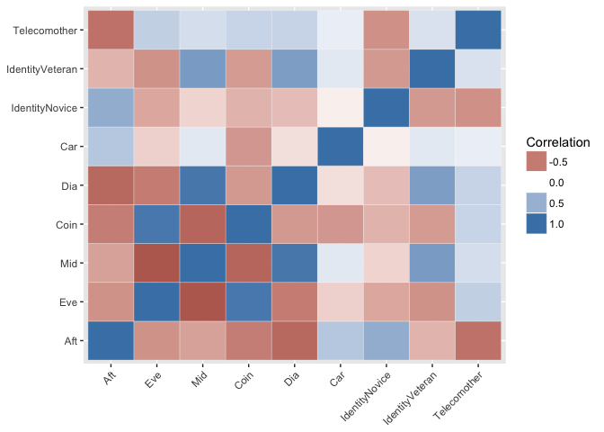

```r
ggplot( data = CorMatrix) +

  geom_tile(aes(Var1, Var2,fill = value), colour = "white") +

  scale_fill_gradient2(low = "firebrick4", high = "steelblue") +

  guides(fill=guide_legend(title="Correlation")) +

  theme(axis.text.x = element_text(angle = 45, hjust = 1, vjust = 1),
        axis.title = element_blank())
```

接著我們選擇用`階層式集群分析`作為資料探索的方法，利用`dist()`函數計算距離後，再用`hclust()`函數進行分析及繪圖。

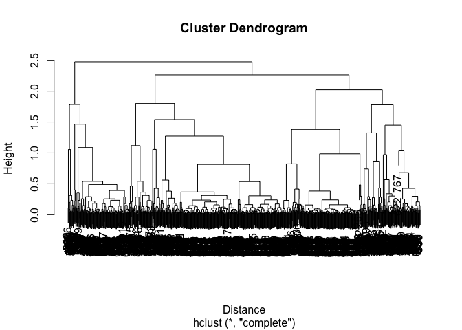

```r
set.seed(500)
Distance <- dist(GameTable, method = 'euclidean')

hclust(Distance, method = 'complete') %>% plot()
```

觀察此圖，我們可以發現，玩家大致上可以被分為3到4個群體，因此以下的建模將以這3、4兩種群數分別討論。

## 資料建模與分析

### 1. 分為三群

用`kmeans()`演算法，決定分群數目後、進行分群後，先看看各個群體中的玩家數量

```r
# Implement Kmeans Algorithm:
set.seed(500) # remove the random effect
K <- kmeans(GameTable,3)

ClusterResult <- cbind(
  GameTable,
  K$cluster
) %>% as.data.frame()

colnames(ClusterResult)[ncol(ClusterResult)] <- 'Cluster'

table(ClusterResult$Cluster)
```

```
##
##   1   2   3
## 253 445 222
```

接著探討個群體間的`連續變數分配`，為了將資料轉換成整齊的格式，這邊會用到`gather()`函數將所有的variables併入同一個欄位裡面

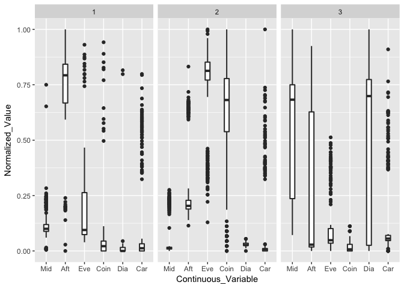

```r
ClusterResultForPlot <- ClusterResult %>%
  gather( key = Continuous_Variable,
          value = Normalized_Value,
          - c(IdentityNovice, IdentityVeteran, Telecomother, Cluster))

ClusterResultForPlot$Continuous_Variable <- ClusterResultForPlot$Continuous_Variable %>% factor( levels = c('Mid','Aft','Eve','Coin','Dia','Car'))

ggplot( data = ClusterResultForPlot) +
  geom_boxplot( aes( x = Continuous_Variable,
                     y = Normalized_Value),
                size = 0.7) +
  facet_wrap( ~ Cluster)
```

由上圖看來，這三個群體中，各個特徵的分布還是較為發散，因此我們推論可以再做進一步的分群，來讓各個特徵的分布更為集中，更容易描述。

### 1. 分為四群

同樣用`kmeans()`演算法進行分群後，先看看各個群體中的玩家數量

```r
# Implement Kmeans Algorithm:
set.seed(500) # remove the random effect
K <- kmeans(GameTable,4)

ClusterResult <- cbind(
  GameTable,
  K$cluster
) %>% as.data.frame()

colnames(ClusterResult)[ncol(ClusterResult)] <- 'Cluster'

table(ClusterResult$Cluster)
```

```
##
##   1   2   3   4
## 239 390 133 158
```

### 群體特徵描述 - 連續變數

- 第一群：上線時間多集中於下午，其他行為較不明顯
- 第二群：上線時間多集中於晚上，有穩定購買金幣的行為
- 第三群：上線時間較分散且較長，有穩定購買卡片的行為
- 第四群：上線時間集中於半夜，有穩定購買鑽石的行為

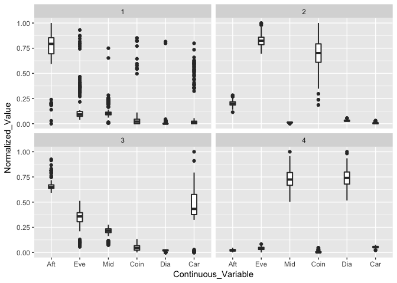

```r
ClusterResultForPlot <- ClusterResult %>%
  gather( key = Continuous_Variable,
          value = Normalized_Value,
          - c(IdentityNovice, IdentityVeteran, Telecomother, Cluster))

ClusterResultForPlot$Continuous_Variable <- ClusterResultForPlot$Continuous_Variable %>% factor( levels = c('Aft','Eve','Mid','Coin','Dia','Car'))

ggplot( data = ClusterResultForPlot) +
  geom_boxplot( aes( x = Continuous_Variable,
                     y = Normalized_Value),
                size = 0.7) +
  facet_wrap( ~ Cluster)
```

### 群體特徵描述 - 類別變數

- 玩家身份

新手多屬於第一個群體，並沒有明顯的購買行為；一般玩家多屬於第二群，在晚上的時間上線並有購買金幣的習慣；老手分布在第三和第四群，又以第四群較多，可以說明抽卡和加值鑽石較能吸引老手群體。

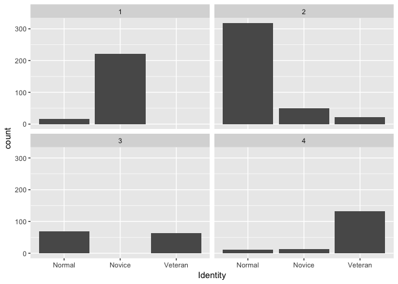

```r
GameTableResult <-  GameLog %>%
  group_by(User_Id) %>%
  summarise(
    Min_Aft = mean(Min_Aft),
    Min_Eve = mean(Min_Eve),
    Min_Mid = mean(Min_Mid),
    Buy_Coin = mean(Buy_Coin),
    Buy_Dia = mean(Buy_Dia),
    Buy_Car = mean(Buy_Car)
  ) %>%
  inner_join(UserTable, by = 'User_Id') %>%
    cbind( K$cluster) %>%
    as.data.frame()

colnames(GameTableResult)[ncol(GameTableResult)] <- 'Cluster'

ggplot( data = GameTableResult) +
  geom_bar( aes( x = Identity)) +
  facet_wrap( ~ Cluster)
```

- 電信業者

屬於ABC電信的玩家在第一群中佔比較高，可以推論ABC電信的用戶為學生較多，與其合作的行銷活動並沒有辦法成功讓該群體的玩家進行遊戲內購買

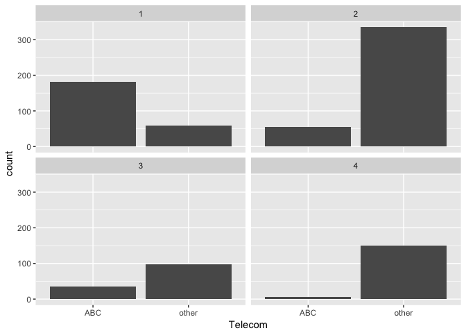

```r
ggplot( data = GameTableResult) +
  geom_bar( aes( x = Telecom)) +
  facet_wrap( ~ Cluster)
```

## 分群結果的視覺化 - 納入主成份分析

- 使用行為(連續變數)的分群

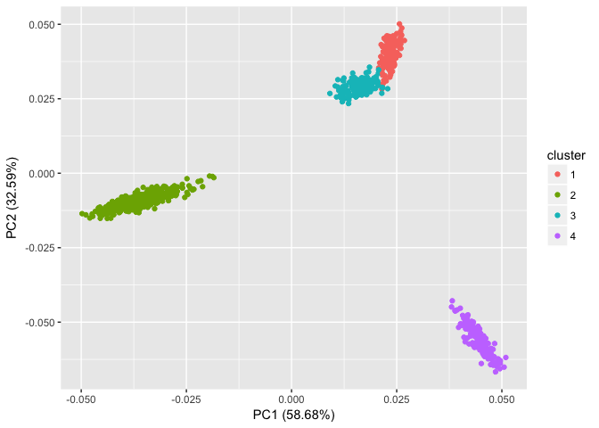

```r
library(ggfortify)
set.seed(500)
autoplot(kmeans(GameTable[,1:6], 4), data  = GameTable)
```

## 針對遊戲營運提出建議

若要增加遊戲內購買，可以針對不同群體提出以下活動：

- 針對群體一群體一多為新手及學生，較沒有明顯的購買行為，可以透過下午時段限定優惠、學生限定優惠、新手加值優惠等方案，針對群體一進行促銷。
- 針對群體三群體三整體的上線時間較長，且購買以抽卡為主，建議提供總上線時間的獎勵，提高抽中稀有卡片的機率，以促進群體三的購買行為。
- 針對群體四群體四的總購買金額最高、上線時間較特別，可以針對該時段設計與其他購買項目的聯合限定促銷，或是獎勵長期玩家的活動，增加群體四的購買金額。
- 針對全部群體由於各個群體的購買項目皆非常集中，可以嘗試各項目間的聯合促銷活動，擴展其他購買項目的銷售機會

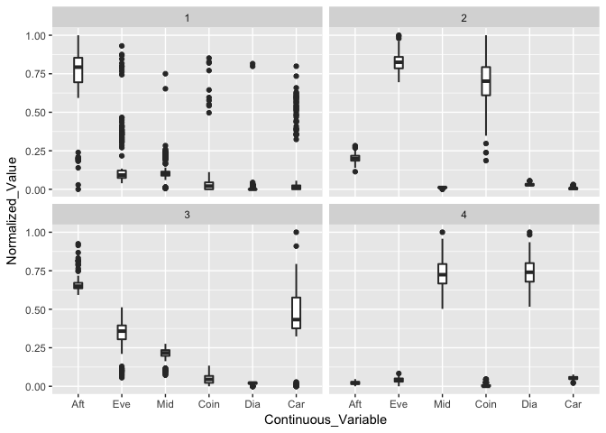

```r
ggplot( data = ClusterResultForPlot) +
  geom_boxplot( aes( x = Continuous_Variable,
                     y = Normalized_Value),
                size = 0.7) +
  facet_wrap( ~ Cluster)
```